# SOTA Stats

Kate Isaac

2025-10-08

```r
library(here)
library(tidyverse)
library(ggVennDiagram)
library(magrittr)
library(patchwork)
```

```r
resultsTidy <- readRDS(here("data/wrangled_data/resultsTidy_personas.rds"))
source(here("resources/scripts/shared_functions.R"))
```

```r
poll_opening_day <- "2024-02-15"
poll_closing_day <- "2024-03-25"
nresponses <- nrow(resultsTidy)
```

```r
Mode <- function(x) {
  ux <- unique(x)
  ux[which.max(tabulate(match(x, ux)))]
}
```

### Response Distribution

Responses made at the beginning of the Results section describing responses received have code supporting them here.

**Code for making tables to look at the response distribution data**

```r
socialMedia <-data.frame(
  media = c("AnVIL-mailing-list", "X", "FH-Data Slack" , "X", "X", "X", "AnVIL-mailing-list", "X"),
  date = ymd(c("2024-02-15", "2024-02-15", "2024-02-16", "2024-02-26", "2024-03-05", "2024-03-11", "2024-03-13", "2024-03-14")))
```

```r
allDatesDf <- data.frame(date = ymd(seq.Date(as.Date(poll_opening_day), as.Date(poll_closing_day), by = "days")), count = 0)

responseDf <- resultsTidy %>%
  select(Timestamp, UserType, FurtherSimplifiedDegrees, institutionID) %>%
  mutate(date = ymd(as_date(ymd_hms(Timestamp)))) %>%
  group_by(date, UserType, FurtherSimplifiedDegrees, institutionID) %>%
  summarize(count = n())
```

[output not shown]

```r
toPlot <- right_join(responseDf, allDatesDf, by="date") %>%
  mutate(count = coalesce(count.x, count.y)) %>% #this is setting days without a timestamp to 0 and adding a 0 to days with responses
  select(!c(count.x, count.y))

responses_only <- toPlot %>%
  ungroup() %>%
  select(date, count) %>%
  group_by(date) %>%
  summarize(daily_count = sum(count))
```

**Code supporting the above statement**

```r
plot_aesthetics <- function(gplot, ylabel = "", xticks = TRUE, legend = FALSE, bar = FALSE, xmin=ymd(as.Date(poll_opening_day)), xmax=ymd(as.Date(poll_closing_day))){
  gplot <- gplot +
    theme_bw() +
    xlab("") +
    ylab(ylabel)

  if(bar){
    gplot <- gplot +
      scale_x_date(limits=c(xmin-1, xmax+1), breaks = seq.Date(xmin, xmax, by="days"), labels = seq.Date(xmin, xmax, by="days"))
  } else{
    gplot <- gplot +
      scale_x_date(limits=c(xmin, xmax), breaks = seq.Date(xmin, xmax, by="days"), labels = seq.Date(xmin, xmax, by="days"))
  }

  if(xticks){
    gplot <- gplot +
      theme(axis.text.x = element_text(angle = 45, hjust=1))
  } else{
    gplot <- gplot +
      theme(axis.text.x = element_blank())
  }

  if(legend){
    gplot <- gplot +
      theme(legend.position = "bottom")
  } else{
    gplot <- gplot +
      theme(legend.position = "none")
  }

  return(gplot)
}

p1 <- toPlot %>%
  ungroup() %>%
  select(date, count) %>%
  group_by(date) %>%
  summarize(daily_count = sum(count)) %>%
  ggplot(aes(x = date, y = daily_count)) +
  geom_point() +
  geom_line()

p1 <- plot_aesthetics(p1, ylabel = "Daily Response Count", xticks = FALSE)

p2 <- left_join(allDatesDf, socialMedia, by='date', relationship = "many-to-many") %>%
  drop_na() %>%
  ggplot(aes(x = date, y = -1, color = media)) +
  geom_jitter(width=0, height=0.2)

p2 <- plot_aesthetics(p2, ylabel = "Recruitment", legend = TRUE) +
  theme(axis.text.y = element_blank(),
        axis.ticks.y = element_blank())
```

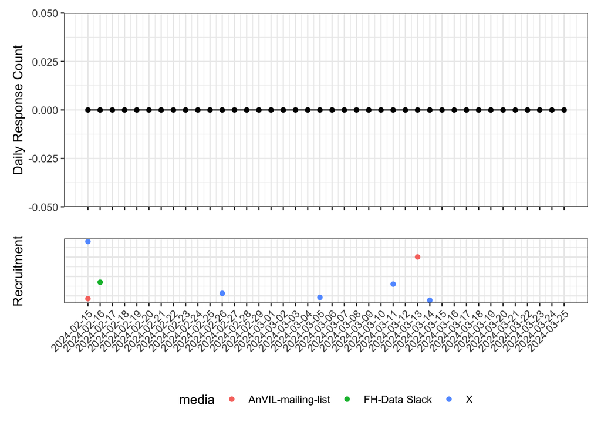

```r
p1 / p2 + plot_layout(heights = c(3,1))
```

**Code supporting the above statement**

```r
paste0("Unique days of advertisement (at least): ", length(unique(socialMedia$date)))
```

```
## [1] "Unique days of advertisement (at least): 7"
```

See plot in above subsection for pattern

**Code supporting the above statement**

```r
highest_days <- responses_only %>% arrange(-daily_count) %>% head(2)

highest_days
```

```
## # A tibble: 2 × 2
##   date       daily_count
##   <date>           <dbl>
## 1 2024-02-15           0
## 2 2024-02-16           0
```

```r
highest_days$date %in% socialMedia$date
```

```
## [1] TRUE TRUE
```

```r
socialMedia[which(socialMedia$date == highest_days$date[1] | socialMedia$date == highest_days$date[2]),]
```

```
##                media       date
## 1 AnVIL-mailing-list 2024-02-15
## 2                  X 2024-02-15
## 3      FH-Data Slack 2024-02-16
```

**Code supporting the above statement**

```r
paste0("Average daily response count: ", mean(responses_only$daily_count)) #1.25
```

```
## [1] "Average daily response count: 0"
```

**Code supporting the above statement**

```r
most_common <- Mode(responses_only$daily_count)

paste0("Most common daily response count: ", most_common) #0
```

```
## [1] "Most common daily response count: 0"
```

```r
paste0("Number of days with 0 reponses : ", sum(responses_only$daily_count == most_common))#21 days with 0 responses
```

```
## [1] "Number of days with 0 reponses : 40"
```

**Code supporting the above statement**

```r
responses_only_nz <- responses_only %>%
  filter(daily_count >=1) #filter out days with a response count of 0

most_common_withoutZeros <- Mode(responses_only_nz$daily_count)
paste0("Most common daily response count (ignoring days without responses): ", most_common_withoutZeros) #1
```

```
## [1] "Most common daily response count (ignoring days without responses): NA"
```

```r
paste0("Number of days with ", most_common_withoutZeros, " responses: ", sum(responses_only$daily_count == most_common_withoutZeros)) #8 days with 1 response
```

```
## [1] "Number of days with NA responses: NA"
```

> When considering the institutional affiliation of respondents, there were no higher than 2 responses from users from the same instutitution on any one day.

The raw institutional affiliation was removed from the tidy data since it could be identifying, however, we used an institutional ID in place of it that we can check.

**Code making a plot to support the above statement**

```r
p3 <- toPlot %>%
  ungroup() %>%
  select(date, institutionID, count) %>%
  group_by(date, institutionID) %>%
  summarize(daily_inst_count = sum(count)) %>%
  drop_na() %>%
  ggplot(aes(x = date, y = daily_inst_count, fill = institutionID)) +
  geom_bar(stat="identity", color = 'white')
p3 <- plot_aesthetics(p3, ylabel = "Institutional Responses", bar = TRUE, xticks = FALSE) + scale_fill_viridis_d()
```

[figure not shown]

```r
p3 / p2 + plot_layout(heights = c(3,1))
```

**Code supporting the above statement**

```r
toPlot %>%
  ungroup() %>%
  select(date, institutionID, count) %>%
  group_by(date, institutionID) %>%
  summarize(daily_inst_count = sum(count)) %>%
  drop_na() %>%
  filter(daily_inst_count > 2)
```

```
## # A tibble: 0 × 3
## # Groups:   date [0]
## # ℹ 3 variables: date <date>, institutionID <fct>, daily_inst_count <dbl>
```

**Code to make a plot to support the above statement**

```r
p4 <- toPlot %>%
  ungroup() %>%
  select(date, UserType, count) %>%
  group_by(date, UserType) %>%
  summarize(daily_usertype_count = sum(count)) %>%
  drop_na() %>%
  ggplot(aes(x = date, y = daily_usertype_count, fill = UserType)) +
  geom_bar(stat = "identity")
p4 <- plot_aesthetics(p4, ylabel = "Usertype Responses", legend = TRUE, bar = TRUE, xticks = FALSE)
```

[figure not shown]

```r
p4 / p2 + plot_layout(heights = c(3,1))
```

### User background and current work

Statements made throughout the “User background and current work” Results section have code supporting them here.

#### Figure 2A - User Type

**Making a table for this data/question on identifying user type of the respondents**

```r
usageDF <- resultsTidy %>%
  select(c(CurrentUsageDescription, UserType)) %>%
  table() %>%
  as.data.frame() %>%
  mutate(percent = Freq / nresponses * 100) %>%
  arrange(-Freq) %>%
  filter(Freq != 0)



return_n <- sum(usageDF[which(usageDF$UserType == "Returning User"), "Freq"])
potential_n <- sum(usageDF[which(usageDF$UserType == "Potential User"), "Freq"])

usageDF$group_percent <- NA

usageDF[which(usageDF$UserType == "Returning User"), "group_percent"] <- usageDF[which(usageDF$UserType == "Returning User"), "Freq"] / return_n * 100

usageDF[which(usageDF$UserType == "Potential User"), "group_percent"] <- usageDF[which(usageDF$UserType == "Potential User"), "Freq"] / potential_n * 100

usageDF
```

```
##                                                             CurrentUsageDescription
## 1           For ongoing projects (e.g., consistent project development and/or work)
## 2                            I do not currently use the AnVIL, but have in the past
## 3                                 I have never used the AnVIL, but have heard of it
## 4   For short-term projects (e.g., short, intense bursts separated by a few months)
## 5                                                   I have never heard of the AnVIL
## 6 For completed/long-term projects (e.g., occasional updates/maintenance as needed)
##         UserType Freq percent group_percent
## 1 Returning User   16      32     72.727273
## 2 Potential User   13      26     46.428571
## 3 Potential User   13      26     46.428571
## 4 Returning User    5      10     22.727273
## 5 Potential User    2       4      7.142857
## 6 Returning User    1       2      4.545455
```

> 44% (n=22) were returning user responses

**Code supporting the above statement**

```r
colSums(usageDF[which(usageDF$UserType == "Returning User"), c("Freq", "percent")])
```

```
##    Freq percent
##      22      44
```

> 56% (n=28) were potential users

**Code supporting the above statement**

```r
colSums(usageDF[which(usageDF$UserType == "Potential User"), c("Freq", "percent")])
```

```
##    Freq percent
##      28      56
```

> The majority of returning user responses (73%, n=16) belonged to the group who use the AnVIL for ongoing projects.

**Code supporting the above statement**

```r
usageDF %>%
  filter(UserType == "Returning User") %>%
  head(1) %>%
  select(CurrentUsageDescription, Freq, group_percent)
```

```
##                                                   CurrentUsageDescription Freq
## 1 For ongoing projects (e.g., consistent project development and/or work)   16
##   group_percent
## 1      72.72727
```

> The majority of potential users were evenly split between two groups (46%, n=13 each), those who have never used the AnVIL (but have heard of it) and those who have used the AnVIL previously, but don’t currently.

**Code supporting the above statement**

```r
usageDF %>%
  filter(UserType == "Potential User") %>%
  head(2) %>%
  select(CurrentUsageDescription, Freq, group_percent)
```

```
##                                  CurrentUsageDescription Freq group_percent
## 1 I do not currently use the AnVIL, but have in the past   13      46.42857
## 2      I have never used the AnVIL, but have heard of it   13      46.42857
```

#### Figure 2B - Degree

**Making a table for this data/question on degrees of respondents**

```r
degreeDF <- resultsTidy$FurtherSimplifiedDegrees %>%
  table() %>%
  as.data.frame() %>%
  mutate(percent = Freq / nresponses * 100) %>%
  arrange(-Freq)

degreeDF
```

```
##                                  . Freq percent
## 1             PhD (or in progress)   31      62
## 2 Master's degree (or in progress)    9      18
## 3                Bachelor's degree    6      12
## 4  MD (MD, MD/PhD, or in progress)    3       6
## 5        High School or equivalent    1       2
```

> Most respondents had obtained or were in the process of obtaining a PhD (62%, n=31)

**Code supporting the above statement**

```r
degreeDF %>%
  filter(str_detect(., "^PhD"))
```

```
##                      . Freq percent
## 1 PhD (or in progress)   31      62
```

> Clinical advanced degrees (MDs) (6%, n=3)

**Code supporting the above statement**

```r
degreeDF %>%
  filter(str_detect(., "MD"))
```

```
##                                 . Freq percent
## 1 MD (MD, MD/PhD, or in progress)    3       6
```

> Master’s degrees (18%, n=9)

**Code supporting the above statement**

```r
degreeDF %>%
  filter(str_detect(., "Master"))
```

```
##                                  . Freq percent
## 1 Master's degree (or in progress)    9      18
```

#### Figure 2C - Institution

**Making a table for this data/question on institutional affiliation**

```r
instDF <- resultsTidy %>%
  select(c(UserType, FurtherSimplifiedInstitutionalType)) %>%
  table() %>%
  as.data.frame() %>%
  mutate(percent = Freq / nresponses * 100) %>%
  arrange(-Freq)

instDF
```

```
##         UserType FurtherSimplifiedInstitutionalType Freq percent
## 1 Potential User                 Research Intensive   22      44
## 2 Returning User                 Research Intensive   21      42
## 3 Potential User                   Industry & Other    4       8
## 4 Potential User                  Education Focused    2       4
## 5 Returning User                  Education Focused    1       2
## 6 Returning User                   Industry & Other    0       0
```

> Most of the respondents using the AnVIL (n=21) reported being affiliated with a research intensive institution

**Code supporting the above statement**

```r
instDF %>%
  filter(UserType == "Returning User") %>%
  head(1) %>%
  select(FurtherSimplifiedInstitutionalType, Freq)
```

```
##   FurtherSimplifiedInstitutionalType Freq
## 1                 Research Intensive   21
```

> one [using the AnVIL] reported being affiliated with an education focused institution

**Code supporting the above statement**

```r
instDF %>%
  filter(UserType == "Returning User") %>%
  filter(str_detect(FurtherSimplifiedInstitutionalType, "Education")) %>%
  select(FurtherSimplifiedInstitutionalType, Freq)
```

```
##   FurtherSimplifiedInstitutionalType Freq
## 1                  Education Focused    1
```

> Only potential users of the platform reported being affiliated with an industry-based institution

**Code supporting the above statement**

```r
instDF %>%
  filter(str_detect(FurtherSimplifiedInstitutionalType, "Industry")) %>%
  select(UserType, FurtherSimplifiedInstitutionalType, Freq)
```

```
##         UserType FurtherSimplifiedInstitutionalType Freq
## 1 Potential User                   Industry & Other    4
## 2 Returning User                   Industry & Other    0
```

#### Consortia

**Making a table for this data/question on consortia affiliations**

```r
consortiaDF <- resultsTidy %>%
  mutate(ConsortiaAffiliations = str_replace_all(ConsortiaAffiliations, c(";|&| and"), ",")) %>%
  separate_longer_delim(ConsortiaAffiliations,
           delim=", ") %>%
  mutate(ConsortiaAffiliations =
           recode(ConsortiaAffiliations,
            "member tech dev group" = "AnVIL",
            "AnVIL Clinical Resource" = "AnVIL",
            "AnVIL " = "AnVIL"
           )
         ) %>%
  group_by(ConsortiaAffiliations, UserType) %>%
  summarize(count = n()) %>%
  drop_na() %>%
  arrange(-count)
```

> Of the 50 responses, 21 provided consortia affiliations

**Code supporting the above statement**

```r
sum(!is.na(resultsTidy$ConsortiaAffiliations))
```

```
## [1] 21
```

> across 23 unique affiliations

**Code supporting the above statement**

```r
n_groups(consortiaDF)
```

```
## [1] 23
```

> Of the 21 responses providing consortia affiliations, 13 were from returning users

**Code supporting the above statement**

```r
sum(resultsTidy[which(!is.na(resultsTidy$ConsortiaAffiliations)),"UserType"] == "Returning User")
```

```
## [1] 13
```

> GREGoR, PRIMED, eMERGE, CCDG, GTEx were the top 5 most represented with n=3 each for GREGoR, PRIMED, and eMERGE and n=2 each for CCDG and GTEx.

**Code supporting the above statement**

```r
consortiaDF %>%
  summarize(sum_count = sum(count)) %>%
  arrange(-sum_count) %>%
  filter(ConsortiaAffiliations != "AnVIL") %>%
  head(n=5)
```

```
## # A tibble: 5 × 2
##   ConsortiaAffiliations sum_count
##   <chr>                     <int>
## 1 GREGoR                        3
## 2 PRIMED                        3
## 3 eMERGE                        3
## 4 CCDG                          2
## 5 GTEx                          2
```

> all 5 of these consortia were represented in the subset of consortia affiliations reported by returning users

**Code supporting the above statement**

```r
consortiaDF %>%
  filter(UserType == "Returning User") %>%
  filter(str_detect(ConsortiaAffiliations, "GREGoR|PRIMED|eMERGE|CCDG|GTEx")) %>%
  summarize(present = count > 0)
```

```
## # A tibble: 5 × 2
##   ConsortiaAffiliations present
##   <chr>                 <lgl>
## 1 CCDG                  TRUE
## 2 GREGoR                TRUE
## 3 GTEx                  TRUE
## 4 PRIMED                TRUE
## 5 eMERGE                TRUE
```

#### Figure 3A - Research Experience

> 21 respondents report that they are extremely experienced in analyzing human genomic data

**Code supporting the above statement**

```r
table(resultsTidy$HumanGenomicExperience)["Extremely experienced"]
```

```
## Extremely experienced
##                    21
```

> only 6 respondents report that they are not at all experienced in analyzing human genomic data

**Code supporting the above statement**

```r
table(resultsTidy$HumanGenomicExperience)["Not at all experienced"]
```

```
## Not at all experienced
##                      6
```

> However, for human clinical data and non-human genomic data, more respondents report being not at all experienced in analyzing those data than report being extremely experienced

**Code supporting the above statement**

```r
sum(resultsTidy$NonHumanGenomicExperience == "Not at all experienced") > sum(resultsTidy$NonHumanGenomicExperience == "Extremely experienced")
```

```
## [1] TRUE
```

```r
sum(resultsTidy$HumanClinicalExperience == "Not at all experienced") > sum(resultsTidy$HumanClinicalExperience == "Extremely experienced")
```

```
## [1] TRUE
```

#### Figure 3A - Research Experience Overlap

> When limiting the responses we consider to include only respondents who reported being “moderately” or “extremely” experienced for at least one of the categories, we are left with 37 responses (17 from returning users)

**Code supporting the above statement**

```r
top_two_box <- resultsTidy %>%
  filter(humanGenomicFlag | clinicalFlag | nonHumanGenomicFlag) %>%
  select(UserType) %>%
  table()
```

```r
top_two_box_n <- sum(top_two_box)
top_two_box_n
```

```
## [1] 37
```

```r
top_two_box["Returning User"]
```

```
## Returning User
##             17
```

> 32% (n=12) reported these levels of experience for all 3 research categories

**Code supporting the above statement**

Count (n = ):

```r
resultsTidy %>%
  filter(humanGenomicFlag == TRUE & clinicalFlag == TRUE & nonHumanGenomicFlag == TRUE) %>%
  nrow()
```

```
## [1] 12
```

Percent:

```r
resultsTidy %>%
  filter(humanGenomicFlag == TRUE & clinicalFlag == TRUE & nonHumanGenomicFlag == TRUE) %>%
  nrow() / top_two_box_n * 100
```

```
## [1] 32.43243
```

> 27% (n=10) reported this level of experience for only human genomic research (but no other research categories)

**Code supporting the above statement**

Count (n = )

```r
resultsTidy %>%
  filter(humanGenomicFlag == TRUE & clinicalFlag == FALSE & nonHumanGenomicFlag == FALSE) %>%
  nrow()
```

```
## [1] 10
```

Percent:

```r
resultsTidy %>%
  filter(humanGenomicFlag == TRUE & clinicalFlag == FALSE & nonHumanGenomicFlag == FALSE) %>%
  nrow() / top_two_box_n * 100
```

```
## [1] 27.02703
```

> 16% (n=6) reported this level of experience for both human clinical and human genomic research (but not non-human genomic research)

**Code supporting the above statement**

Count (n = )

```r
resultsTidy %>%
  filter(humanGenomicFlag == TRUE & clinicalFlag == TRUE & nonHumanGenomicFlag == FALSE) %>%
  nrow()
```

```
## [1] 6
```

Percent:

```r
resultsTidy %>%
  filter(humanGenomicFlag == TRUE & clinicalFlag == TRUE & nonHumanGenomicFlag == FALSE) %>%
  nrow() / top_two_box_n * 100
```

```
## [1] 16.21622
```

> another 16% (n=6) reported this level of experience in analyzing both non-human and human genomic research

**Code supporting the above statement**

Count (n =):

```r
resultsTidy %>%
  filter(humanGenomicFlag == TRUE & clinicalFlag == FALSE & nonHumanGenomicFlag == TRUE) %>%
  nrow()
```

```
## [1] 6
```

Percent:

```r
resultsTidy %>%
  filter(humanGenomicFlag == TRUE & clinicalFlag == FALSE & nonHumanGenomicFlag == TRUE) %>%
  nrow() / top_two_box_n * 100
```

```
## [1] 16.21622
```

#### Figure 4 - Kind of Work

**Making a table for this data/question on kind of work selections**

```r
kindOfWorkDF <-
  resultsTidy %>%
  select(TimestampID, KindOfWork) %>%
  separate_longer_delim(KindOfWork, delim = ", ") %>%
  mutate(
    KindOfWork = recode(KindOfWork, "Program administration," = "Program administration", "computational education" = "Computational education"),
    value = TRUE
  ) %>%
  pivot_wider(names_from = KindOfWork, values_from = value, values_fill = FALSE)
```

> 44% (n=22) selected only 1 description, 36% (n=18) selected 2 descriptions, 16% (n=8) selected 3 descriptions, and 4% (n=2) selected 5 descriptions.

**Code supporting the above statement**

```r
numSelected <- kindOfWorkDF %>%
  select(!TimestampID) %>%
  rowSums()

numSelectedDF <- tibble("num_descriptions_selected" = numSelected) %>%
  count(num_descriptions_selected) %>%
  mutate(percentage_responses = round(n / nresponses * 100, 0))

numSelectedDF
```

```
## # A tibble: 4 × 3
##   num_descriptions_selected     n percentage_responses
##                       <dbl> <int>                <dbl>
## 1                         1    22                   44
## 2                         2    18                   36
## 3                         3     8                   16
## 4                         5     2                    4
```

> “Computational work” was the most frequently selected response, reported by 68% of respondents (n=34)

**Code supporting the above statement**

```r
numResponsesPerDescription <- data.frame("n" = colSums(kindOfWorkDF[, 2:ncol(kindOfWorkDF)])) %>%
  rownames_to_column("work_description") %>%
  mutate(percentage_responses = round(n / nresponses * 100, 0)) %>%
  arrange(-n)

numResponsesPerDescription %>% head(1)
```

```
##     work_description  n percentage_responses
## 1 Computational work 34                   68
```

> “Project management” at 36% (n=18)

**Code supporting the above statement**

```r
numResponsesPerDescription %>% filter(str_detect(work_description, "management"))
```

```
##     work_description  n percentage_responses
## 1 Project management 18                   36
```

> “Project leadership” at 24% (n=12) respectively.

**Code supporting the above statement**

```r
numResponsesPerDescription %>% filter(str_detect(work_description, "leadership"))
```

```
##     work_description  n percentage_responses
## 1 Project leadership 12                   24
```

> Of the 22 respondents who selected only 1 description,

**Code supporting the above statement**

```r
singleResponseRows <- which(rowSums(kindOfWorkDF[2:ncol(kindOfWorkDF)]) == 1) # these rows are responses where they only provided one description

singleResponseDF <- tibble("description" = unlist(lapply(1:length(singleResponseRows), function(x) colnames(kindOfWorkDF)[which(kindOfWorkDF[singleResponseRows[x], ] == TRUE)]))) %>% # for those rows, find the corresponding columns that are true and add the column names to a vector
  count(description) %>% # count the number of times each of those descriptions is there
  mutate(percentage_singleResponses = n / sum(n) * 100) %>%
  arrange(-n) # arrange in descending order

singleResponseDF %>%
  select(n) %>%
  sum()
```

```
## [1] 22
```

> “Computational work” was the most frequently selected (n=13, 59%) [of only 1 description]

**Code supporting the above statement**

```r
singleResponseDF %>% head(1)
```

```
## # A tibble: 1 × 3
##   description            n percentage_singleResponses
##   <chr>              <int>                      <dbl>
## 1 Computational work    13                       59.1
```

> Of the responses who selected more than one description, “Computational work” was paired most frequently with “Project management” or “Project leadership”. (n=11 and 7 respectively)

**Code supporting the above statement**

```r
find_pairs <- function(inputDF, rowOI) {
  pairs <- c()
  notNA_cols_combos <- t(combn(which(inputDF[rowOI, ] == TRUE), 2)) # rows will be indices for each pair
  for (rowIndex in 1:nrow(notNA_cols_combos)) {
    pairs <- c(pairs, paste0(unlist(colnames(inputDF)[notNA_cols_combos[rowIndex, ]]), collapse = "-"))
  }
  return(pairs)
}
```

```r
kindOfWorkDF_subset <- kindOfWorkDF[which(rowSums(kindOfWorkDF[, 2:ncol(kindOfWorkDF)]) > 1), -c(1)]

pairs_all <- unlist(lapply(
  1:nrow(kindOfWorkDF_subset),
  function(x) find_pairs(kindOfWorkDF_subset, x)
)) %>%
  as.data.frame() %>%
  `colnames<-`(c("pairs")) %>%
  group_by(pairs) %>%
  mutate(count = n()) %>%
  ungroup() %>%
  distinct() %>%
  arrange(-count)

print(pairs_all, n = nrow(pairs_all))
```

```
## # A tibble: 26 × 2
##    pairs                                      count
##    <chr>                                      <int>
##  1 Computational work-Project management         11
##  2 Computational work-Project leadership          7
##  3 Project leadership-Project management          6
##  4 Computational work-Engineering work            5
##  5 Project management-Program administration      4
##  6 Computational work-Wet lab work                3
##  7 Project leadership-Program administration      2
##  8 Project leadership-Clinical work               2
##  9 Wet lab work-Wet lab education                 2
## 10 Wet lab work-Program administration            2
## 11 Computational work-Computational education     2
## 12 Project management-Computational education     2
## 13 Computational work-Program administration      1
## 14 Project management-Wet lab education           1
## 15 Computational work-Wet lab education           1
## 16 Wet lab education-Computational education      1
## 17 Program administration-Wet lab education       1
## 18 Wet lab work-Project leadership                1
## 19 Wet lab work-Project management                1
## 20 Wet lab work-Clinical work                     1
## 21 Project management-Clinical work               1
## 22 Program administration-Clinical work           1
## 23 Project leadership-Engineering work            1
## 24 Project leadership-Computational education     1
## 25 Project management-Engineering work            1
## 26 Engineering work-Computational education       1
```

#### Figure 4 - Personas

**Making a table for this data/question on personas of respondents**

```r
personaDF <- resultsTidy %>%
  select(c(persona, UserType)) %>%
  table() %>%
  as.data.frame() %>%
  arrange(-Freq)

personaDF
```

```
##          persona       UserType Freq
## 1             PI Potential User    8
## 2        Analyst Returning User    7
## 3        Analyst Potential User    6
## 4  None assigned Returning User    6
## 5             PI Returning User    5
## 6          Admin Potential User    4
## 7       Educator Potential User    4
## 8  None assigned Potential User    4
## 9          Admin Returning User    3
## 10     Clinician Potential User    2
## 11      Educator Returning User    1
## 12     Clinician Returning User    0
```

> 10 respondents were left uncategorized

**Code supporting the above statement**

```r
personaDF %>%
  filter(persona == "None assigned") %>%
  select(Freq) %>%
  sum()
```

```
## [1] 10
```

> majority of respondents were assigned to either the Leadership (PI) persona (n=13, showing evidence of computational work together with some form of project management, leadership, or administration) or the Analyst persona (n=13, only reporting computational work)

**Code supporting the above statement**

```r
personaDF %>%
  group_by(persona) %>%
  summarize(sum = sum(Freq)) %>%
  arrange(-sum) %>%
  head(2)
```

```
## # A tibble: 2 × 2
##   persona   sum
##   <fct>   <int>
## 1 Analyst    13
## 2 PI         13
```

> 7 respondents were categorized as an Admin persona

**Code supporting the above statement**

```r
personaDF %>%
  filter(persona == "Admin") %>%
  select(Freq) %>%
  sum()
```

```
## [1] 7
```

> 2 potential users were assigned a Clinician persona because of selecting clinical work (this option was not selected by returning users)

**Code supporting the above statement**

```r
personaDF %>%
  filter(persona == "Clinician")
```

```
##     persona       UserType Freq
## 1 Clinician Potential User    2
## 2 Clinician Returning User    0
```

> 4 potential users were assigned an Educator persona while only 1 returning user was

**Code supporting the above statement**

```r
personaDF %>%
  filter(persona == "Educator")
```

```
##    persona       UserType Freq
## 1 Educator Potential User    4
## 2 Educator Returning User    1
```

### Barriers & user preferences

Statements made throughout the “Barriers & user preferences” Results section have code supporting them here.

#### Important Features by Persona

**Code to make a plot for the observations in this section**

```r
totalRanksdfPersona <-
  bind_rows(
    #Clinician
    resultsTidy %>%
      filter(persona == "Clinician") %>%
      select(contains("Rank")) %>%
      colSums(na.rm = TRUE) %>%
      as.data.frame() %>% `colnames<-`(c("totalRank")) %>%
      mutate(nranks = sum(resultsTidy$persona == "Clinician"),
             persona = "Clinician"),
    #Analyst
    resultsTidy %>%
      filter(persona == "Analyst") %>%
      select(contains("Rank")) %>%
      colSums(na.rm = TRUE) %>%
      as.data.frame() %>% `colnames<-`(c("totalRank")) %>%
      mutate(nranks = sum(resultsTidy$persona == "Analyst"),
            persona = "Analyst"),
    # Educator
    resultsTidy %>%
      filter(persona == "Educator") %>%
      select(contains("Rank")) %>%
      colSums(na.rm = TRUE) %>%
      as.data.frame() %>% `colnames<-`(c("totalRank")) %>%
      mutate(nranks = sum(resultsTidy$persona == "Educator"),
            persona = "Educator"),
    #PI
    resultsTidy %>%
      filter(persona == "PI") %>%
      select(contains("Rank")) %>%
      colSums(na.rm = TRUE) %>%
      as.data.frame() %>% `colnames<-`(c("totalRank")) %>%
      mutate(nranks = sum(resultsTidy$persona == "PI"),
             persona = "PI"),
    #Admin
    resultsTidy %>%
      filter(persona == "Admin") %>%
      select(contains("Rank")) %>%
      colSums(na.rm = TRUE) %>%
      as.data.frame() %>% `colnames<-`(c("totalRank")) %>%
      mutate(nranks = sum(resultsTidy$persona == "Admin"),
             persona = "Admin"),
    #None assigned
    resultsTidy %>%
      filter(persona == "None assigned") %>%
      select(contains("Rank")) %>%
      colSums(na.rm = TRUE) %>%
      as.data.frame() %>% `colnames<-`(c("totalRank")) %>%
      mutate(nranks = sum(resultsTidy$persona == "None assigned"),
              persona = "None Assigned")
  ) %>%
  mutate(UsertypeFeature = rownames(.)) %>%
  separate(UsertypeFeature, c("Usertype", "FeatureExtra"), sep = "Rank", remove = TRUE) %>%
  separate(FeatureExtra, c("Feature", "extra"), sep = "\\.", remove = TRUE) %>%
  mutate(Feature =
    case_when(Feature == "EasyBillingSetup" ~ "Easy billing setup",
              Feature == "FlatRateBilling" ~ "Flat-rate billing rather than use-based",
              Feature == "FreeVersion" ~ "Free version with limited compute or storage",
              Feature == "SupportDocs" ~ "On demand support and documentation",
              Feature == "ToolsData" ~ "Specific tools or datasets are available/supported",
              Feature == "CommunityAdoption" ~ "Greater adoption of the AnVIL by the scientific community")
  ) %>%
  group_by(persona, Feature, nranks) %>%
  summarize(totalRankAcrossUsertype = sum(totalRank)) %>%
  mutate(avgRank = totalRankAcrossUsertype / nranks)
totalRanksdfPersona %>% arrange(avgRank)
```

```
## # A tibble: 36 × 5
## # Groups:   persona, Feature [36]
##    persona       Feature                   nranks totalRankAcrossUsert…¹ avgRank
##    <chr>         <chr>                      <int>                  <dbl>   <dbl>
##  1 Clinician     Free version with limite…      2                      2    1
##  2 Clinician     On demand support and do…      2                      2    1
##  3 Clinician     Specific tools or datase…      2                      2    1
##  4 Educator      Free version with limite…      5                      7    1.4
##  5 Clinician     Greater adoption of the …      2                      3    1.5
##  6 PI            Specific tools or datase…     13                     20    1.54
##  7 Educator      Greater adoption of the …      5                      8    1.6
##  8 Admin         Free version with limite…      7                     13    1.86
##  9 None Assigned Specific tools or datase…     10                     19    1.9
## 10 Educator      On demand support and do…      5                     10    2
## # ℹ 26 more rows
## # ℹ abbreviated name: ¹totalRankAcrossUsertype
```

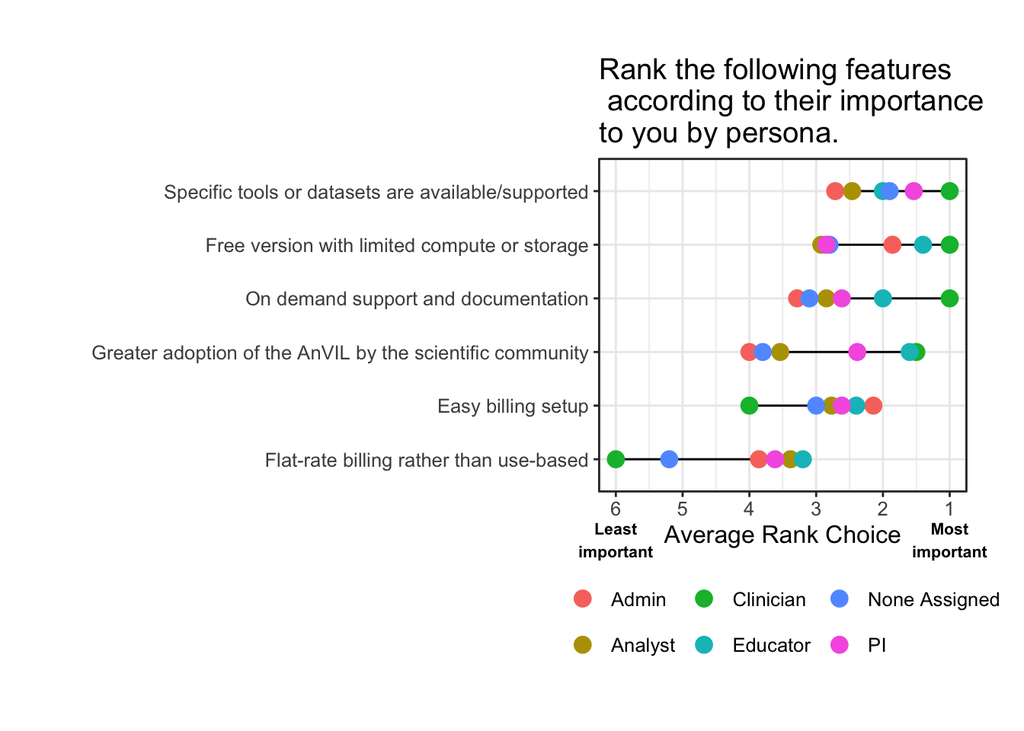

```r
gpdumbbell <- ggplot(totalRanksdfPersona,
aes(x = avgRank,
y = reorder(Feature, -avgRank))) +
geom_line() +
geom_point(aes(color = persona), size = 3.5) +
ggtitle("Rank the following features\n according to their importance\nto you by persona.")
gpdumbbell %<>% stylize_dumbbell(xmax=6, importance = TRUE, usertype = FALSE) +
  theme(text = element_text(size=12))
```

All 3 of the observations below are made from the plot above and by looking at the total ranks data frame (`totalRanksdfPersona`)

> When looking at responses specific to the assigned personas, we observe that the average rank choice for easy billing setup is highest for Admins compared to other personas

> Educators and Clinicians rank both a free version with limited compute or storage and greater adoption by the scientific community more highly than other personas

> PIs rank having specific tools or datasets available/supported as their most important feature of AnVIL

#### Awareness - Figure 6

> Potential users were split at 46% (n=13) knowing about monthly AnVIL Demos or the support forum

**Code supporting the above statement**

Counts observed in the plot (6B, 6D)

Awareness Percentage:

```r
resultsTidy %>%
  filter(UserType == "Potential User") %>%
  filter(forumAwareness == "Aware of") %>%
  nrow() / potential_n * 100
```

```
## [1] 46.42857
```

> and 54% (n=15) not being aware of the support opportunities

**Code supporting the above statement**

Counts observed in the plot (6B, 6D)

Not aware of Percentage:

```r
resultsTidy %>%
  filter(UserType == "Potential User") %>%
  filter(forumAwareness == "Not Aware of") %>%
  nrow() / potential_n * 100
```

```
## [1] 53.57143
```

If we look at this by defining a column of aware of either, these numbers don’t match, suggesting that there are not always matching aware/not aware answers for both support options

**Code supporting the above statement**

```r
resultsTidy %>%
  select(c(UserType, forumAwareness, AnVILDemoAwareness)) %>%
  mutate(supportAwareness = forumAwareness == "Aware of" | AnVILDemoAwareness == "Aware of") %>%
  group_by(UserType) %>%
  summarize(sumAware = sum(supportAwareness))
```

```
## # A tibble: 2 × 2
##   UserType       sumAware
##   <fct>             <int>
## 1 Potential User       17
## 2 Returning User       18
```

> only 71% (n=20) of potential users had matching aware/not aware responses for both AnVIL Demos and the support forum

**Code supporting the above statement**

Count (n = ):

```r
potential_matching <- resultsTidy %>%
  filter(UserType == "Potential User") %>%
  mutate(matching = forumAwareness == AnVILDemoAwareness) %>%
  select(matching) %>%
  sum()

potential_matching
```

```
## [1] 20
```

Percentage:

```r
potential_matching / potential_n * 100
```

```
## [1] 71.42857
```

> Of the 15 not aware respondents, only 73% (n=11) were not aware of both AnVIL Demos and the support forum

**Code supporting the above statement**

Count (n = )

```r
potential_na_matching <- resultsTidy %>%
  filter(UserType == "Potential User") %>%
  filter(forumAwareness == "Not Aware of" | AnVILDemoAwareness == "Not Aware of") %>%
  mutate(matching = forumAwareness == AnVILDemoAwareness) %>%
  select(matching) %>%
  sum()

potential_na_matching
```

```
## [1] 11
```

Percentage:

```r
potential_na_matching / 15 * 100
```

```
## [1] 73.33333
```

> Similarly, 86% (n=19) of returning users had matching aware/not aware responses for both AnVIL Demos and the support forum

**Code supporting the above statement**

Count (n = )

```r
returning_matching <- resultsTidy %>%
  filter(UserType == "Returning User") %>%
  mutate(matching = forumAwareness == AnVILDemoAwareness) %>%
  select(matching) %>%
  sum()

returning_matching
```

```
## [1] 19
```

Percentage:

```r
returning_matching / return_n * 100
```

```
## [1] 86.36364
```

> Only 4 returning user responses were not aware of both the AnVIL Demos or the support forum

**Code supporting the above statement**

```r
returning_na_matching <- resultsTidy %>%
  filter(UserType == "Returning User") %>%
  filter(forumAwareness == "Not Aware of" | AnVILDemoAwareness == "Not Aware of") %>%
  mutate(matching = forumAwareness == AnVILDemoAwareness) %>%
  select(matching) %>%
  sum()

returning_na_matching
```

```
## [1] 4
```

> Returning users showed a higher percentage of respondents who were aware of the support opportunities (n=16, 73% and n=17, 77%)

**Code supporting the above statement**

Counts observed in the plot (6B, 6D)

Demo Percentage:

```r
resultsTidy %>%
  filter(UserType == "Returning User") %>%
  filter(AnVILDemoAwareness == "Aware of") %>%
  nrow() / return_n * 100
```

```
## [1] 72.72727
```

Forum Percentage:

```r
resultsTidy %>%
  filter(UserType == "Returning User") %>%
  filter(forumAwareness == "Aware of") %>%
  nrow() / return_n * 100
```

```
## [1] 77.27273
```

> Returning users are also more represented in the group of respondents who have attended AnVIL Demos (n=12 or 71% of attenders)

**Code supporting the above statement**

Count (n = ):

```r
resultsTidy %>%
  filter(UserType == "Returning User") %>%
  filter(str_detect(AnVILDemo, "Yes")) %>%
  nrow()
```

```
## [1] 12
```

Percentage:

```r
resultsTidy %>%
  filter(UserType == "Returning User") %>%
  filter(str_detect(AnVILDemo, "Yes")) %>%
  nrow() /
resultsTidy %>%
  filter(str_detect(AnVILDemo, "Yes")) %>%
  nrow() * 100
```

```
## [1] 70.58824
```

> [Returning users] utilized the support forum (n=8 or 67% of those who have read through, posted, or replied in this sample)

**Code supporting the above statement**

Count (n = ):

```r
resultsTidy %>%
  filter(UserType == "Returning User") %>%
  filter(str_detect(AnVILSupportForum, "Answered|Posted|Read")) %>%
  nrow()
```

```
## [1] 8
```

Percentage:

```r
resultsTidy %>%
  filter(UserType == "Returning User") %>%
  filter(str_detect(AnVILSupportForum, "Answered|Posted|Read")) %>%
  nrow() /
  resultsTidy %>%
  filter(str_detect(AnVILSupportForum, "Answered|Posted|Read")) %>%
  nrow() * 100
```

```
## [1] 66.66667
```

> most poll respondents have not attended AnVIL Demos with only 34% (n=17) reporting attendance

**Code supporting the above statement**

Count (n = ):

```r
resultsTidy %>%
  filter(str_detect(AnVILDemo, "Yes")) %>%
  nrow()
```

```
## [1] 17
```

Percentage:

```r
resultsTidy %>%
  filter(str_detect(AnVILDemo, "Yes")) %>%
  nrow() / nresponses * 100
```

```
## [1] 34
```

> Most respondents have not utilized the support forum with only 24% (n=12) in some way reporting use

**Code supporting the above statement**

Count (n = ):

```r
resultsTidy %>%
  filter(str_detect(AnVILSupportForum, "Answered|Posted|Read")) %>%
  nrow()
```

```
## [1] 12
```

Percentage:

```r
resultsTidy %>%
  filter(str_detect(AnVILSupportForum, "Answered|Posted|Read")) %>%
  nrow() / nresponses * 100
```

```
## [1] 24
```

### User technological comfort

Statements made throughout the “User technological comfort” Results section have code supporting them here.

#### Where analyses are run

**Making a table for this data/question on where respondents run analyses**

```r
runLocDF <- resultsTidy %>%
  separate_longer_delim(WhereAnalysesRun, ", ") %>%
  mutate(WhereAnalysesRun =
           recode(WhereAnalysesRun,
                  "Amazon Web Services (AWS)" = "AWS",
                  "Galaxy (usegalaxy.org)" = "Galaxy",
                  "Galaxy Australia" = "Galaxy",
                  "Google Cloud Platform (GCP)" = "GCP",
                  "Institutional High Performance Computing cluster (HPC)" = "Institutional HPC",
                  "Personal computer (locally)," = "Personal computer (locally)",
                  "local server" = "Institutional HPC")
         ) %>%
  select(c(UserType, WhereAnalysesRun)) %>%
  table() %>%
  as.data.frame() %>%
  mutate(percent = Freq / nresponses * 100) %>%
  arrange(-Freq)

runLocDF$group_percent <- NA
runLocDF[which(runLocDF$UserType == "Returning User"), "group_percent"] <- runLocDF[which(runLocDF$UserType == "Returning User"), "Freq"] / return_n * 100

runLocDF[which(runLocDF$UserType == "Potential User"), "group_percent"] <- runLocDF[which(runLocDF$UserType == "Potential User"), "Freq"] / potential_n * 100

runLocDF
```

```
##          UserType            WhereAnalysesRun Freq percent group_percent
## 1  Potential User Personal computer (locally)   22      44     78.571429
## 2  Potential User           Institutional HPC   21      42     75.000000
## 3  Returning User           Institutional HPC   14      28     63.636364
## 4  Returning User                         GCP   12      24     54.545455
## 5  Returning User Personal computer (locally)   12      24     54.545455
## 6  Potential User                         GCP    9      18     32.142857
## 7  Potential User                         AWS    5      10     17.857143
## 8  Potential User                      Galaxy    5      10     17.857143
## 9  Returning User                         AWS    4       8     18.181818
## 10 Returning User             Microsoft Azure    2       4      9.090909
## 11 Potential User                   All of Us    1       2      3.571429
## 12 Returning User                      Galaxy    1       2      4.545455
## 13 Potential User             Microsoft Azure    1       2      3.571429
## 14 Potential User               sciserver.org    1       2      3.571429
## 15 Potential User                    UKBB RAP    1       2      3.571429
## 16 Returning User                   All of Us    0       0      0.000000
## 17 Returning User               sciserver.org    0       0      0.000000
## 18 Returning User                    UKBB RAP    0       0      0.000000
```

> Institutional High Performance Computers (HPCs) 70%, n=35

**Code supporting the above statement**

```r
colSums(runLocDF[which(str_detect(runLocDF$WhereAnalysesRun, "HPC")), c("Freq", "percent")])
```

```
##    Freq percent
##      35      70
```

> 64% of returning users

**Code supporting the above statement**

```r
runLocDF %>%
  filter(UserType == "Returning User") %>%
  filter(str_detect(WhereAnalysesRun, "HPC")) %>%
  select(group_percent)
```

```
##   group_percent
## 1      63.63636
```

> 75% of potential users

**Code supporting the above statement**

```r
runLocDF %>%
  filter(UserType == "Potential User") %>%
  filter(str_detect(WhereAnalysesRun, "HPC")) %>%
  select(group_percent)
```

```
##   group_percent
## 1            75
```

> locally on personal computers (68%, n=34)

**Code supporting the above statement**

```r
colSums(runLocDF[which(str_detect(runLocDF$WhereAnalysesRun, "locally")), c("Freq", "percent")])
```

```
##    Freq percent
##      34      68
```

> 55% of returning users

**Code supporting the above statement**

```r
runLocDF %>%
  filter(UserType == "Returning User") %>%
  filter(str_detect(WhereAnalysesRun, "locally")) %>%
  select(group_percent)
```

```
##   group_percent
## 1      54.54545
```

> 79% of potential users

**Code supporting the above statement**

```r
runLocDF[which(str_detect(runLocDF$WhereAnalysesRun, "locally") & runLocDF$UserType == "Potential User"), "Freq"] / potential_n * 100
```

```
## [1] 78.57143
```

> For provided cloud options, GCP was reported as used the most (n=21) split across user types

**Code supporting the above statement**

```r
runLocDF %>%
  filter(str_detect(WhereAnalysesRun, "Azure|GCP|AWS")) %>%
  group_by(WhereAnalysesRun) %>%
  summarize(across(c(Freq, percent), sum, .names = "sum_{.col}")) %>%
  arrange(-sum_Freq)
```

```
## # A tibble: 3 × 3
##   WhereAnalysesRun sum_Freq sum_percent
##   <fct>               <int>       <dbl>
## 1 GCP                    21          42
## 2 AWS                     9          18
## 3 Microsoft Azure         3           6
```

> (55% of returning users)

**Code supporting the above statement**

```r
runLocDF %>%
  filter(UserType == "Returning User") %>%
  filter(str_detect(WhereAnalysesRun, "GCP")) %>%
  select(group_percent)
```

```
##   group_percent
## 1      54.54545
```

> (and 32% of potential users)

**Code supporting the above statement**

```r
runLocDF %>%
  filter(UserType == "Potential User") %>%
  filter(str_detect(WhereAnalysesRun, "GCP")) %>%
  select(group_percent)
```

```
##   group_percent
## 1      32.14286
```

> We also observed that potential users report using Galaxy (a free option)(18%, n=5), more than returning users do (5%, n=1)

**Code supporting the above statement**

```r
runLocDF[which(str_detect(runLocDF$WhereAnalysesRun, "Galaxy")),c("WhereAnalysesRun", "Freq", "group_percent")]
```

```
##    WhereAnalysesRun Freq group_percent
## 8            Galaxy    5     17.857143
## 12           Galaxy    1      4.545455
```

> Potential users also submitted All of Us, sciserver.org, and UKBB RAP as other platforms

**Code supporting the above statement**

```r
runLocDF %>%
  filter(str_detect(WhereAnalysesRun, "Us|sciserver|RAP"))
```

```
##         UserType WhereAnalysesRun Freq percent group_percent
## 1 Potential User        All of Us    1       2      3.571429
## 2 Potential User    sciserver.org    1       2      3.571429
## 3 Potential User         UKBB RAP    1       2      3.571429
## 4 Returning User        All of Us    0       0      0.000000
## 5 Returning User    sciserver.org    0       0      0.000000
## 6 Returning User         UKBB RAP    0       0      0.000000
```

### User resource and data needs

Statements made throughout the “User resource and data needs” Results section have code supporting them here.

#### Foreseeable computational needs

**Making a table for this data/question on requested computational/storage resources**

```r
computationalNeedOverlap <-
  list(storageList =
       which(str_detect(resultsTidy$NeededResources, "storage")),
     nodesList =
       which(str_detect(resultsTidy$NeededResources, "nodes")),
     gpuList =
       which(str_detect(resultsTidy$NeededResources, "GPUs")),
     memoryList =
       which(str_detect(resultsTidy$NeededResources, "memory")))


overlap_table <- process_region_data(Venn(computationalNeedOverlap))
overlap_table
```

```
## # A tibble: 15 × 4
##    id      name                                     item      count
##    <chr>   <chr>                                    <list>    <int>
##  1 1       storageList                              <int [7]>     7
##  2 2       nodesList                                <int [1]>     1
##  3 3       gpuList                                  <int [3]>     3
##  4 4       memoryList                               <int [1]>     1
##  5 1/2     storageList/nodesList                    <int [1]>     1
##  6 1/3     storageList/gpuList                      <int [0]>     0
##  7 1/4     storageList/memoryList                   <int [1]>     1
##  8 2/3     nodesList/gpuList                        <int [2]>     2
##  9 2/4     nodesList/memoryList                     <int [0]>     0
## 10 3/4     gpuList/memoryList                       <int [0]>     0
## 11 1/2/3   storageList/nodesList/gpuList            <int [0]>     0
## 12 1/2/4   storageList/nodesList/memoryList         <int [1]>     1
## 13 1/3/4   storageList/gpuList/memoryList           <int [0]>     0
## 14 2/3/4   nodesList/gpuList/memoryList             <int [0]>     0
## 15 1/2/3/4 storageList/nodesList/gpuList/memoryList <int [1]>     1
```

> The most common response was needing large amounts of storage (e.g., Terabytes), selected by 50% (n=11)

**Code supporting the above statement**

```r
length(computationalNeedOverlap$storageList)
```

```
## [1] 11
```

```r
length(computationalNeedOverlap$storageList) / return_n * 100
```

```
## [1] 50
```

> 32% (n=7) only selected this option [of large storage]

**Code supporting the above statement**

```r
overlap_table %>%
  filter(name == "storageList")
```

```
## # A tibble: 1 × 4
##   id    name        item      count
##   <chr> <chr>       <list>    <int>
## 1 1     storageList <int [7]>     7
```

```r
overlap_table %>%
  filter(name == "storageList") %>%
  select(count) / return_n * 100
```

```
##      count
## 1 31.81818
```

> Many nodes 27%

**Code supporting the above statement**

```r
length(computationalNeedOverlap$nodesList) / return_n * 100
```

```
## [1] 27.27273
```

> GPUs 27%

**Code supporting the above statement**

```r
length(computationalNeedOverlap$gpuList) / return_n * 100
```

```
## [1] 27.27273
```

> large memory 18%

**Code supporting the above statement**

```r
length(computationalNeedOverlap$memoryList) / return_n * 100
```

```
## [1] 18.18182
```

> Only 1 response selected all 4 computational need

**Code supporting the above statement**

```r
overlap_table %>%
  filter(id == "1/2/3/4")
```

```
## # A tibble: 1 × 4
##   id      name                                     item      count
##   <chr>   <chr>                                    <list>    <int>
## 1 1/2/3/4 storageList/nodesList/gpuList/memoryList <int [1]>     1
```

> The most common combination of selections was GPUs and many nodes (n=2)

**Code supporting the above statement**

```r
overlap_table %>%
  filter(str_detect(id, "/")) %>%
  arrange(-count) %>%
  head(1)
```

```
## # A tibble: 1 × 4
##   id    name              item      count
##   <chr> <chr>             <list>    <int>
## 1 2/3   nodesList/gpuList <int [2]>     2
```

> All other combinations were only selected once or not at all

**Code supporting the above statement**

```r
overlap_table %>%
  filter(str_detect(id, "/")) %>%
  filter(name != "nodesList/gpuList") %>%
  select(count) %>%
  unique()
```

```
## # A tibble: 2 × 1
##   count
##   <int>
## 1     1
## 2     0
```

> 11 possible combinations of multiple options

**Code supporting the above statement**

```r
noptions <- resultsTidy %>%
  separate_longer_delim(NeededResources, ", ") %>%
  select(NeededResources) %>%
  drop_na() %>%
  filter(NeededResources != "I don't know") %>%
  unique() %>%
  nrow()

npossible <- 0
for (i in c(2:noptions)){
  npossible <- npossible + choose(noptions, i)
}

npossible
```

```
## [1] 11
```

#### DMS repository

**Making a table for this data/question on data sharing repositories for DMS Policy**

```r
dmsDFwUT <- resultsTidy %>%
  separate_longer_delim(RepositoriesDMS, ", ") %>%
  separate_longer_delim(RepositoriesDMS, delim=" & ") %>%
  mutate(RepositoriesDMS =
           case_when(
             str_detect(RepositoriesDMS, regex("dbgap", ignore_case = TRUE)) ~ "dbGaP",
             .default = as.character(RepositoriesDMS)
                     )
         ) %>%
  select(c(UserType, RepositoriesDMS)) %>%
  table() %>%
  as.data.frame() %>%
  mutate(percent = Freq / nresponses * 100) %>%
  arrange(-Freq)

dmsDFwUT$group_percent <- NA
dmsDFwUT[which(dmsDFwUT$UserType == "Returning User"), "group_percent"] <- dmsDFwUT[which(dmsDFwUT$UserType == "Returning User"), "Freq"] / return_n * 100

dmsDFwUT[which(dmsDFwUT$UserType == "Potential User"), "group_percent"] <- dmsDFwUT[which(dmsDFwUT$UserType == "Potential User"), "Freq"] / potential_n * 100

dmsDFwUT
```

```
##          UserType                 RepositoriesDMS Freq percent group_percent
## 1  Returning User                           AnVIL   15      30     68.181818
## 2  Potential User   Your institutional repository   13      26     46.428571
## 3  Potential User                           AnVIL    8      16     28.571429
## 4  Potential User                          Zenodo    8      16     28.571429
## 5  Returning User   Your institutional repository    6      12     27.272727
## 6  Returning User                           dbGaP    5      10     22.727273
## 7  Potential User I'm not sure what DMS Policy is    5      10     17.857143
## 8  Returning User I'm not sure what DMS Policy is    5      10     22.727273
## 9  Potential User                           dbGaP    4       8     14.285714
## 10 Returning User                          Zenodo    4       8     18.181818
## 11 Returning User                             GEO    2       4      9.090909
## 12 Returning User                             SRA    2       4      9.090909
## 13 Returning User                BioData Catalyst    1       2      4.545455
## 14 Potential User                             EGA    1       2      3.571429
## 15 Returning User                          ENCODE    1       2      4.545455
## 16 Potential User                          GitHub    1       2      3.571429
## 17 Potential User                    Google Drive    1       2      3.571429
## 18 Potential User                            NeMO    1       2      3.571429
## 19 Potential User                             SRA    1       2      3.571429
## 20 Potential User                BioData Catalyst    0       0      0.000000
## 21 Returning User                             EGA    0       0      0.000000
## 22 Potential User                          ENCODE    0       0      0.000000
## 23 Potential User                             GEO    0       0      0.000000
## 24 Returning User                          GitHub    0       0      0.000000
## 25 Returning User                    Google Drive    0       0      0.000000
## 26 Returning User                            NeMO    0       0      0.000000
```

> 46% (n=23) of all respondents flagged the AnVIL as a repository that they use or are considering use of to share data to comply with the NIH DMS policy

**Code supporting the above statement**

```r
dmsDFwUT %>%
  filter(RepositoriesDMS == "AnVIL") %>%
  summarize(across(c(Freq, percent), sum, .names = "sum_{.col}"))
```

```
##   sum_Freq sum_percent
## 1       23          46
```

> Of those 23, 65% (n=15) were returning users of the AnVIL

**Code supporting the above statement**

```r
returning_selectedAnVIL <- dmsDFwUT %>%
  filter(RepositoriesDMS == "AnVIL") %>%
  filter(UserType == "Returning User") %>%
  select(Freq) %>% unlist() %>% unname()

returning_selectedAnVIL
```

```
## [1] 15
```

```r
returning_selectedAnVIL / sum(dmsDFwUT[which(dmsDFwUT$RepositoriesDMS == "AnVIL"), "Freq"]) * 100
```

```
## [1] 65.21739
```

> (68% of the returning user sample of this community poll)

**Code supporting the above statement**

```r
dmsDFwUT %>%
  filter(UserType == "Returning User") %>%
  filter(RepositoriesDMS == "AnVIL") %>%
  select(group_percent)
```

```
##   group_percent
## 1      68.18182
```

#### Controlled Access Data Sets

> Over half of all respondents (n=29) reported that they are “extremely interested” in working with controlled access datasets

**Code supporting the above statement**

```r
extremely_interested_respondents <- unname(table(resultsTidy$InterestControlledData)[5])

extremely_interested_respondents
```

```
## [1] 29
```

```r
extremely_interested_respondents / nresponses * 100
```

```
## [1] 58
```

**Making a table for this data/question on specific interest in controlled access data**

```r
controlledDataDF <- resultsTidy %>%
  separate_longer_delim(AccessWhichControlledData, ", ") %>%
  select(AccessWhichControlledData) %>%
  table() %>%
  as.data.frame() %>%
  mutate(percent = Freq/ nresponses * 100) %>%
  arrange(-Freq)

controlledDataDF
```

```
##                                                AccessWhichControlledData Freq
## 1                                                             All of Us*   34
## 2                                                            UK Biobank*   34
## 3                          The Genotype-Tissue Expression Project (GTEx)   32
## 4                             Centers for Common Disease Genomics (CCDG)   20
## 5                        The Human Pangenome Reference Consortium (HPRC)   19
## 6  Genomics Research to Elucidate the Genetics of Rare Diseases (GREGoR)   18
## 7                       Electronic Medical Records and Genomics (eMERGE)   17
## 8                               The Centers for Mendelian Genomics (CMG)   15
## 9                                     Gabriella Miller Kids First (GMKF)   12
## 10                                     Undiagnosed Disease Network (UDN)   12
## 11               Clinical Sequencing Evidence-Generating Research (CSER)   11
## 12        Population Architecture Using Genomics and Epidemiology (PAGE)    8
## 13                                                                  TCGA    2
## 14                        Being able to pull other dbGap data as needed.    1
```

[output cut: 21 more lines]

> All of Us and UK Biobank were the most selected (n=34 each)

**Code supporting the above statement**

```r
controlledDataDF %>%
  head(2)
```

```
##   AccessWhichControlledData Freq percent
## 1                All of Us*   34      68
## 2               UK Biobank*   34      68
```

> GTEx was selected by 64% (n=32)

**Code supporting the above statement**

```r
controlledDataDF %>%
  filter(str_detect(AccessWhichControlledData, "GTEx"))
```

```
##                       AccessWhichControlledData Freq percent
## 1 The Genotype-Tissue Expression Project (GTEx)   32      64
```

> CCDG was selected by 40% (n=20)

**Code supporting the above statement**

```r
controlledDataDF %>%
  filter(str_detect(AccessWhichControlledData, "CCDG"))
```

```
##                    AccessWhichControlledData Freq percent
## 1 Centers for Common Disease Genomics (CCDG)   20      40
```

#### Different types of data

**Making a table for this data/question on experience with different types of data**

```r
typeOfDataDF <- resultsTidy %>%
    separate_longer_delim(TypesOfData, delim=", ") %>%
    mutate(TypesOfData =
               recode(TypesOfData,
                      "I don't analyze data on AnVIL" = NA_character_,
                      "I store data in AnVIL. I don’t analyze it." = NA_character_,
                      "Used in training for analysis of genomes (variant calling)" = "Variant Calling"
               )
    ) %>%
    select(TypesOfData) %>%
    drop_na(TypesOfData) %>% table() %>%
  as.data.frame() %>%
  mutate(percent = Freq / nresponses * 100) %>%
  arrange(-Freq)

typeOfDataDF
```

```
##                 TypesOfData Freq percent
## 1            Genomes/exomes   44      88
## 2            Transcriptomes   31      62
## 3                Phenotypic   20      40
## 4               Single Cell   19      38
## 5                  Metadata   17      34
## 6  Electronic Health Record   15      30
## 7                Epigenomes   14      28
## 8               Metabolomes    9      18
## 9                 Proteomes    8      16
## 10                  Imaging    5      10
## 11              Metagenomes    5      10
## 12                   Survey    4       8
## 13               Structural    2       4
## 14          Variant Calling    1       2
```

> Genomes/exomes (88%, n=44)

**Code supporting the above statement**

```r
typeOfDataDF %>%
  filter(TypesOfData == "Genomes/exomes")
```

```
##      TypesOfData Freq percent
## 1 Genomes/exomes   44      88
```

> Transcriptomes (62%, n=31)

**Code supporting the above statement**

```r
typeOfDataDF %>%
  filter(TypesOfData == "Transcriptomes")
```

```
##      TypesOfData Freq percent
## 1 Transcriptomes   31      62
```

> A variety of other options (e.g., Phenotypic, Single Cell, Electronic Health Record, Epigenomes, Metabolomes, Proteomes, Imaging, etc.) were selected at a rate of at least 10% (n=5), but no more than 40% (n=20)

**Code supporting the above statement**

```r
typeOfDataDF %>%
  filter(percent >= 10) %>%
  filter(percent <= 40)
```

```
##                TypesOfData Freq percent
## 1               Phenotypic   20      40
## 2              Single Cell   19      38
## 3                 Metadata   17      34
## 4 Electronic Health Record   15      30
## 5               Epigenomes   14      28
## 6              Metabolomes    9      18
## 7                Proteomes    8      16
## 8                  Imaging    5      10
## 9              Metagenomes    5      10
```

> Survey, structural, and variant calling were the only options selected or mentioned by fewer than 10% of respondents

**Code supporting the above statement**

```r
typeOfDataDF %>%
  filter(percent < 10)
```

```
##       TypesOfData Freq percent
## 1          Survey    4       8
## 2      Structural    2       4
## 3 Variant Calling    1       2
```